# Feature Visualization

Please find two .ipynb files named “feature vis - mnist.ipynp” and “feature vis - svhn.ipynb” included in the respository All work and images included below can be reproduced from the respective notebooks. To run the code, sequentially run each cell in the IPython notebook. Enabling GPU enhanced runtime in Colab significantly speeds up the training and optimization processes, particularly on the SVHN dataset.

#### Introduction

In this project we implemented an optimization based feature visualization framework. We used a 2-layer CNN and examined the results on both the MNIST and SVHN datasets. With any CNN architecture we can reverse the training process and optimize with respect to the input image rather than the weights of the network. By choosing different optimization objectives we can find images that excite different sections of the network.

The sections of the network we chose to study were the logits, and the convolutional feature maps. By maximizing the logit activation we can find images that the network classifies as a certain category with high probability. By maximizing a convolutional layer we can see what features the convolutional kernels are set to detect.

The main hurdle in optimization based feature visualization is navigating high frequency noise. The space of natural images is a small subset of the input space $\mathbf{R}^{W\times H\times C}$. When we start our optimization from a random image it is likely that we will arrive at a local optimum that is not a natural image. To counter this we need to regularize the optimization.

#### L2 Regularization

One possibility is to use the standard $L^2$ norm as an optimization penalty as in [1]. If $h(\mathbb{x})$ is the feature of the network we wish to activate then the objective function becomes $h(\mathbb{x}) - \lambda \|\mathbb{x}\|_2$. Experimenting with this penalty did not give good results. At best it served to dampen the image but did not lead to visually different images as unconstrained optimization. Shown here are unconstrained and $L^2$ regularized optimization on the 2 and 9 logits for the MNIST data set. The best performance came from using a small $\lambda$ and essentially achieving the same results as unconstrained optimization.

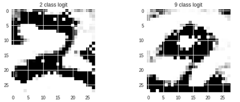

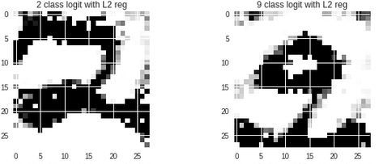

The $L^2$ regularization did nothing to reduce high frequency noise in the activation of the convolutional layers and the results are not shown here.

#### Total Variation Regularization

Another sensible regularizer to try is the total variation norm, as suggested in [2]. The total variation norm penalizes the image for having neighboring pixels of different magnitude. Adjusting the constant on the penalty of the TV norm led to interesting results. On the MNIST dataset we see that using the total variation norm removes the “stem” of the 9 from the optimized output. This may lead us to the hypothesis that the network deems the circular part of the 9 as more important for correct classification.

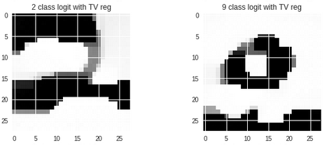

The total variation norm also helped reduce high frequency noise in the convolutional layers. To activate a convolutional feature map we took the objective function to be the mean pixel value of the convolutional output at a certain channel. These features appeared to be more abstract and did not have clear visual interpretations. Below are the results of unconstrained optimization and TV regularization with $\lambda = 0.05$ on a convolutional map from each layer of the network.

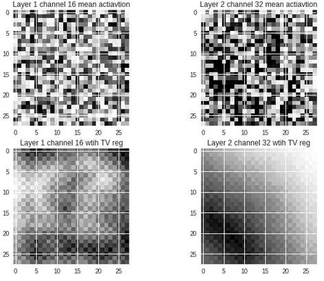

The regularization constant was chosen to strike a balance between image variation and expressiveness, and high frequency noise. Much experimentation was done in choosing a suitable $\lambda$.

The SVHN dataset gave similar results to the MNIST dataset.

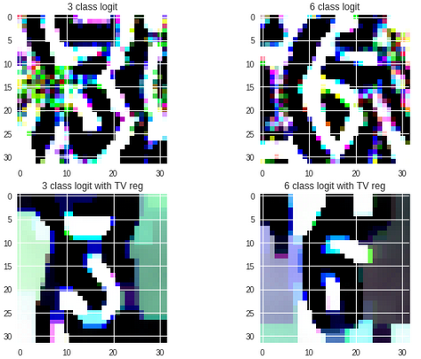

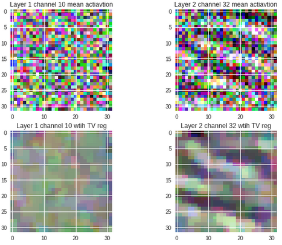

What is intersting to note in the SVHN dataset is the stark contrast between the digit and the surrounding pixels in the optimized class logit examples. This may lead us to the hypothesis that the network is more confident in images that have greater distinction between foregound and background.

#### Gaussian Blur

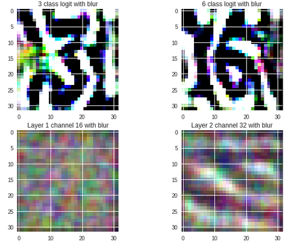

#### Adversarial Images

A similar technique to feature visualization through optimization can be applied to generate so-called adversarial images. These techniquies have been studied and are documented in [4]. Instead of starting with a random image and optimizing to activate a particular class logit, we start with an image from the training set that the network already classifies correctly, and set the objective to a different class. We restrict each pixel value of the output image to be within a certain small interval of the inital image. Doing this allows us to generate samples which look like one class to the human eye, but the network classifies incorrectly with high probability. An example from the SVHN dataset is show below.

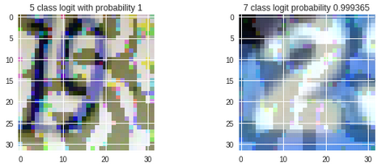

#### References

$\left[1\right]$: K. Simonyan, A. Vedaldi, and A. Zisserman. Deep inside convolutional networks: Visualising image classification models and saliency maps. In $\textit{ICLR workshop}$, 2014.

$\left[2\right]$: A. Mahendran and A. Vedaldi. Visualizing deep convolutional neural networks using natural pre-images. In $\textit{Computer Vision and Pattern Recognition (CVPR)}$, 2016.

$\left[3\right]$: J. Yosinski, J. Clune, A. Nguyen, T. Fuchs, and H. Lipson. Understanding neural networks through deep visualization. In $\textit{Deep Learning Workshop, ICML conference}$, 2015.

$\left[4\right]$: Szegedy, C., Zaremba, W., Sutskever, I., Bruna, J., Erhan, D., Goodfellow, I. and Fergus, R., Intriguing properties of neural networks. In $\textit{arXiv preprint arXiv:1312.6199}$, 2013.